# Module 3 Project, Part C: Resampling Structured Data

# Directions

The project has 5 parts, one for each topic day of Module 3 - Resample, each in its own file. This is Part C. Complete each question, including the appropriate output. This document will be used on the exam. For any question make sure to display any requested output. If you use any AI assistance in implementing the R code, be prepared to explain how the implementation works.

This part is turn-in 3.3, worth 1 point for completion. Knit it to HTML and upload the `.html` file to Canvas.

Helpful hint: remember to knit the document periodically to make sure the project can be knit prior to printing out your paper copy before the exam.

# Data

Part C uses the Capital Bikeshare data from Part A.

```r
bikes <- read.csv("../../data/bikes.csv")
n <- nrow(bikes)
```

# Part C: Resampling structured data

Part A treated the 731 days as independent. C.1 asks whether 2012 was warmer than 2011, using the block bootstrap to keep nearby days together. C.2 compares three ways to bootstrap a regression slope when the error variance changes with $x$, then resamples within each year to compare the two years.

## C.1(a): A seasonal cycle and its residuals

Temperature is not stationary: it follows a yearly cycle. Model it as a cycle plus a 2012 effect plus stationary noise $Z_t$,
$$\text{temp}_t = \beta_0 + \beta_1 \,
\text{y2012}_t + \text{cycle}(d_t) + Z_t,$$
where $d_t$ is the day of the year and y2012 is 1 for days in 2012. The code below fits the model. The sines and cosines fit a smooth yearly cycle.

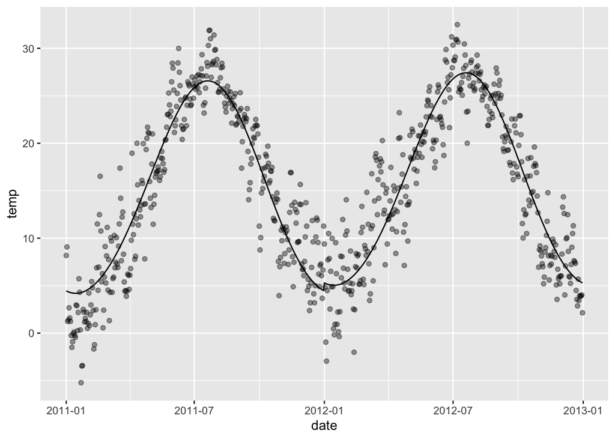

```r
bikes$y2012 <- as.numeric(bikes$year == 2012)
bikes$d <- as.numeric(format(as.Date(bikes$date), "%j"))   # day of the year
fit_temp <- lm(temp ~ y2012 + sin(2 * pi * d / 365) + cos(2 * pi * d / 365) +
                 sin(4 * pi * d / 365) + cos(4 * pi * d / 365), data = bikes)
z <- resid(fit_temp)
ggplot(data.frame(date = as.Date(bikes$date), temp = bikes$temp,
                  fitted = fitted(fit_temp)), aes(date, temp)) +
  geom_point(alpha = 0.4) + geom_line(aes(y = fitted))
```

1. Report the coefficient of `y2012` and its SE from `summary(fit_temp)`.
2. Compute the lag-1 autocorrelation of the residuals `z`, and the autocorrelations to lag 14. By about which lag are they near 0?

## C.1(b): The block bootstrap

`block_boot` is the moving block bootstrap from the deck. `effect(zs)` adds a resampled residual series `zs` to the fitted values and returns the refitted `y2012` coefficient. `lm.fit` refits with the same columns much faster than `lm`.

```r
block_boot <- function(x, stat, B, l) {
  n <- length(x)
  replicate(B, {
    xs <- c()
    while (length(xs) < n) {
      i <- sample(n - l + 1, 1)
      xs <- c(xs, x[i:(i + l - 1)])
    }
    stat(xs[1:n])
  })
}
X <- model.matrix(fit_temp)
effect <- function(zs) coef(lm.fit(X, fitted(fit_temp) + zs))[["y2012"]]
```

1. Compute the block bootstrap SE of the 2012 effect for `ls <- c(1, 3, 5, 7, 10, 14, 21, 30, 45)` with $B = 2000$, and plot it against $\ell$.
2. Which $\ell$ gives about the SE from `summary`, and why? Choose an $\ell$ where the SE has leveled off.
3. Report the 95% normal interval for the 2012 effect with your $\ell$, and with the SE from `summary`. Was 2012 warmer than 2011?

## C.2(a): Three bootstraps for a slope

Now fit `casual ~ temp` to all days. As in Part A, treat the days as independent.

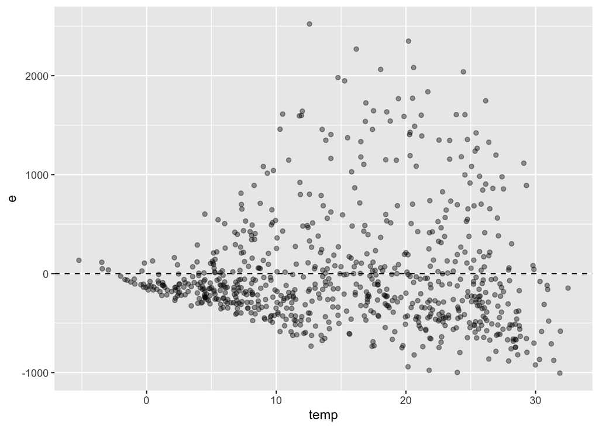

```r
fit_casual <- lm(casual ~ temp, data = bikes)
x <- bikes$temp
y <- bikes$casual
y_hat <- fitted(fit_casual)
e <- resid(fit_casual)
ggplot(data.frame(temp = x, e), aes(temp, e)) + geom_point(alpha = 0.4) +
  geom_hline(yintercept = 0, lty = 2)
```

```r
far <- order(-abs(x - mean(x)))[1:10]   # the 10 days farthest from the mean temp
```

The spread of the residuals grows with temperature.

1. Bootstrap the slope `cov(x, y) / var(x)` with $B = 2000$ by resampling cases, resampling errors, and the wild bootstrap. Report the three SEs and the SE from `summary(fit_casual)`.
2. The days farthest from the mean temperature have the most influence on the slope. Compare the mean $|e_i|$ for the 10 days in `far` with the mean $|e_i|$ for all days.
3. Use (2) to explain why resampling errors disagrees with the wild bootstrap here.

## C.2(b): Comparing the two years

Did ridership grow from 2011 to 2012? Treat the two years as strata. `bikes |> group_by(year) |> slice_sample(prop = 1, replace = TRUE)` draws one bootstrap sample that resamples days within each year.

1. Compute the median of `total` in each year, and the difference, 2012 minus 2011.
2. Bootstrap the difference with $B = 2000$, resampling days within each year.
3. Report the bootstrap SE and the 95% percentile interval. Why resample within each year rather than all 731 days?